# Relación entre perfiles de estudiantes y su desempeño académico

2023-05-05

# **Introducción**

En las universidades existen diferentes tipos de estudiantes, con diferentes características, diferentes rutinas y diferentes estilos de vida, los cuales también obtienen diferentes notas. Muchas veces se dice que para obtener estas notas basta solo con estudiar, pero ¿qué tan real es esto?, estudios realizados como el de [(Chong, E. G)] (https://www.redalyc.org/articulo.oa?id=27050422005), nos muestran cómo existen diversos factores que inciden en el rendimiento académico, además [(Murillo, M. A)] (http://www.ori.soa.efn.uncor.edu/wp-content/uploads/2011/05/Rendimiento-Acad%C3%A9mico-Universitario.pdf), nos presenta variables muy poco conocidas pero muy importantes como las institucionales o pedagógicas las cuales cumplen un rol fundamental en la formación de todo profesional, asimismo,[(Mamani, R. L)] (http://www.revistasbolivianas.ciencia.bo/scielo.php?script=sci_arttext&pid=S2305-60102015000200003&lng=en&nrm=iso&tlng=es) nos hace presenta una investigación descriptiva y cuantitativa de los factores que influyeron a que los estudiantes de la carrera de ingeniería civil pertenecientes a la Universidad Autónoma Juan Misael Saracho obtengan bajas notas, por lo cual te preguntamos ¿ crees qué las notas solo dependen de las horas que estudias al dia? o quizá estas también dependen de otros factores y características. En este sentido analizaremos tales características, rutinas y otras variables y su relación con el desempeño académico. De este modo, con este estudio se identificarán aquellos aspectos que guardan relación directa con las notas y evaluar qué condiciones son causales de altas y bajas notas.

# **Población**

En esta oportunidad, nos centraremos en alumnos de UTEC tomando en cuenta todas las carreras y a los que están cursando el segundo ciclo o ciclos superiores,mediante el uso de encuestas obtendremos las respuestas las cuales luego nos servirán para hacer el respectivo análisis y conclusiones de nuestro estudio.

# **Importancia**

Los estudiantes universitarios de UTEC a lo largo de su vida universitaria necesitan aprobar sus cursos y además de esto lo recomendable es que obtengan buenas notas, muchas veces no conocemos o tenemos ejemplos a seguir, no tenemos una cierta guia de lo qué los estudiantes con mejor rendimiento realicen o quizá cuales son sus características los cuales hacen qué tengan un buen desempeño.

# **Relevancia**

Describir la relación entre perfiles de estudiantes analizando sus hábitos de estudio, horas de sueño, tiempo en llegar a la universidad, nivel socioeconómico, entre otras y ver si estos guardan relación con sus notas obtenidas en ciclos pasados o actuales..

# **Factibilidad**

El estudio a realizar es factible ya que la recolección de datos no sería un problema, utilizaremos las herramientas digitales como google forms para qué los alumnos puedan rellenar sus respuestas, estas herramientas son gratis y fáciles de usar, además que los alumnos ya están acostumbrados a llenar google forms, asimismo, se cuenta con el correo electrónico de los estudiantes de UTEC, lo que facilita el envío de los cuestionarios y garantiza que la muestra sea aleatoria y probabilística.

# **Interes del Público**

A todos los estudiantes les interesa obtener buenas calificaciones y captar los temas con facilidad, al finalizar el estudio podemos concluir qué rutinas, métodos de estudio y características poseen los estudiantes con mayor nota para que los estudiantes que posiblemente obtuvieron notas bajas anteriormente puedan aplicarlas en si mismo de tal manera que puedan mejorar su desempeño académico.

# **1 Datos**

## **1.1 Recolección de Datos**

Los datos obtenidos están en base al muestreo por conveniencia pues el estudio busca recopilar el perfil de cada estudiante para tener una idea de la calidad del estudiante de la UTEC. Se buscó que la encuesta tenga el mayor alcance posible para que todo el alumnado tenga la misma probabilidad de responder. Las estrategias usadas radican en esparcir nuestra encuesta para tener los datos.

Las estrategias son: Esparcir la encuesta entre nuestros círculos sociales de la universidad, mediante el correo compartir nuestra encuesta con aquellos que lo permitieron, de manera presencial lograr que el alumno llene la encuesta.

## **1.2 Población objetivo**

El alumnado pregrado de la UTEC

## **1.3 Unidad muestral**

Alumno pregrado Utec

# Descripción General

Se realizó una encuesta a estudiantes universitarios para conocer características y percepciones importantes sobre su carrera, apoyo familiar, métodos de estudio, entre otros.

## **2.- Objetivos generales y específicos**

### **2.1.- Objetivo General**

Conocer las características más relevantes de los estudiantes de UTEC.

### **2.2.- Objetivos Específico:**

- Diferenciar los atributos sociodemográficos y académicos según género.
- Descubrir correlaciones importantes entre variables edad, promedio ponderado, horas de estudio y horas de descanso.
- Modelar las variables según las distribuciones estudiadas en clase.

## **3.- Descripción General**

Se realizó una encuesta a estudiantes universitarios para conocer características y percepciones importantes sobre su carrera, apoyo familiar, métodos de estudio, entre otros. Las variables se organizaron como:

### **3.1.- Variables cuantitativas**

| Variable | Definición | Tipo de Variable | Restricciones |
| --- | --- | --- | --- |
| Edad | Edad del estudiante | Discreta | Entero entre 14 y 40 |
| H.descanso | Horas de descanso al día | Continua | Racionales entre 0 y 24 con un decimal |
| H.estudio | Horas de estudio al día | Continua | Racionales entre 0 y 24 con un decimal |
| T.traslado | Tiempo de traslado | Continua | Racionales entre 0 y 24 con un decimal |
| P.ciclo | Promedio ponderado | Continua | Racionales entre 0 y 20 con dos decimales |

```r
library(readr)
datos <- read_csv("datos.csv")
head(datos)
```

```
## # A tibble: 6 x 27
##   Variable      Edad Sexo  Carrera Ciclo H.descanso H.estudio E.pagos T.traslado
##   <chr>        <dbl> <chr> <chr>   <dbl>      <dbl>     <dbl> <chr>        <dbl>
## 1 4/26/2022 1~    18 Masc~ Ingeni~     3          6         3 Escala~         60
## 2 4/26/2022 2~    18 Masc~ Ingeni~     4          7         4 Escala~         45
## 3 4/26/2022 2~    19 Masc~ Ingeni~     4          7         4 Escala~         60
## 4 4/26/2022 2~    18 Masc~ Ingeni~     4          5         3 Escala~         75
## 5 4/26/2022 2~    18 Masc~ Ingeni~     2          8         2 Escala~         45
## 6 4/26/2022 2~    19 Masc~ Ingeni~     4          7         3 Escala~         60
## # i 18 more variables: E.laboral <chr>, Hogar <chr>, N.padre <chr>,
## #   N.madre <chr>, Asesorias <chr>, Tertil <chr>, E.colegio <dbl>,
## #   R.textos <dbl>, L.estudio <chr>, E.curso <dbl>, P.ciclo <dbl>,
## #   N.Generales <chr>, N.Carrera <chr>, N.Humanidades <chr>, N.Gestion <chr>,
## #   R.temas <dbl>, S.sentimental <chr>, A.familiar <dbl>
```

Número de casos completos: 200

```r
sum(complete.cases(datos))
```

```
## [1] 200
```

Número de observaciones: 5400

```r
sum(!is.na(datos))
```

```
## [1] 5400
```

## **4.- Estadísticas descriptivas**

Se procedió a crear una función en R que permite obtener las estadísticas descriptivas para las variables numéricas

```r
de=function(x){
  library(modeest)
  n=length(x)
  Promedio=mean(x,na.rm = TRUE)
  Mediana=median(x,na.rm = TRUE)
  Moda=mfv(x)
  P25=as.vector(quantile(x,0.25,na.rm = TRUE))
  P75=as.vector(quantile(x,0.75,na.rm = TRUE))
  Min=min(x,na.rm = TRUE)
  Máx=max(x,na.rm = TRUE)
  Rango=Máx-Min
  Varianza=var(x,na.rm = TRUE)
  DE=sd(x,na.rm = TRUE)
  CV=100*DE/Promedio
  IQR=P75-P25
  resultados=rbind(n,Promedio,Mediana,Moda,P25,P75,Min,Máx,Rango,Varianza,DE,CV,IQR)
  resultados=round(resultados,2)
    return(resultados)
}
est=rownames(de(datos$Edad))
de(datos$Edad)
```

```
##            [,1]
## n        200.00
## Promedio  20.34
## Mediana   20.00
## Moda      20.00
## P25       19.00
## P75       22.00
## Min       17.00
## Máx       24.00
## Rango      7.00
## Varianza   3.19
## DE         1.79
## CV         8.78
## IQR        3.00
```

Esta función se puede aplicar de forma simultánea a todas las variables numéricas con uso de de la libreria dplyr

```r
library(dplyr)
estadisticos=datos %>%
  summarise_at(c("Edad","H.descanso","H.estudio","T.traslado","P.ciclo"),de)
estadisticos=as.data.frame(estadisticos)
names(estadisticos)=c("Edad","H.descanso","H.estudio","T.traslado","P.ciclo")
rownames(estadisticos)=est
library(DT)
library(kableExtra)
estadisticos %>%
  kbl(caption = "Estadisticas descriptivas de variales cuantitativas") %>%
  kable_classic(full_width = F, html_font = "Cambria")
```

Estadisticas descriptivas de variales cuantitativas

|  | Edad | H.descanso | H.estudio | T.traslado | P.ciclo |
| --- | --- | --- | --- | --- | --- |
| n | 200.00 | 200.00 | 200.00 | 200.00 | 200.00 |
| Promedio | 20.34 | 6.85 | 4.37 | 58.24 | 14.29 |
| Mediana | 20.00 | 7.00 | 4.00 | 60.00 | 14.00 |
| Moda | 20.00 | 7.00 | 4.00 | 60.00 | 16.00 |
| P25 | 19.00 | 6.00 | 3.00 | 43.75 | 13.00 |
| P75 | 22.00 | 8.00 | 5.00 | 75.00 | 16.00 |
| Min | 17.00 | 4.00 | 1.00 | 10.00 | 8.00 |
| Máx | 24.00 | 9.00 | 8.00 | 180.00 | 18.97 |
| Rango | 7.00 | 5.00 | 7.00 | 170.00 | 10.97 |
| Varianza | 3.19 | 0.82 | 2.07 | 700.37 | 4.14 |
| DE | 1.79 | 0.90 | 1.44 | 26.46 | 2.04 |
| CV | 8.78 | 13.21 | 32.90 | 45.44 | 14.24 |
| IQR | 3.00 | 2.00 | 2.00 | 31.25 | 3.00 |

### **Interpretación**

#### Edad

De los 200 estudiantes universitarios encuestados:

Según el histograma la edad de los estudiantes se concentra mayormente en edades entre 19 y 22 años.

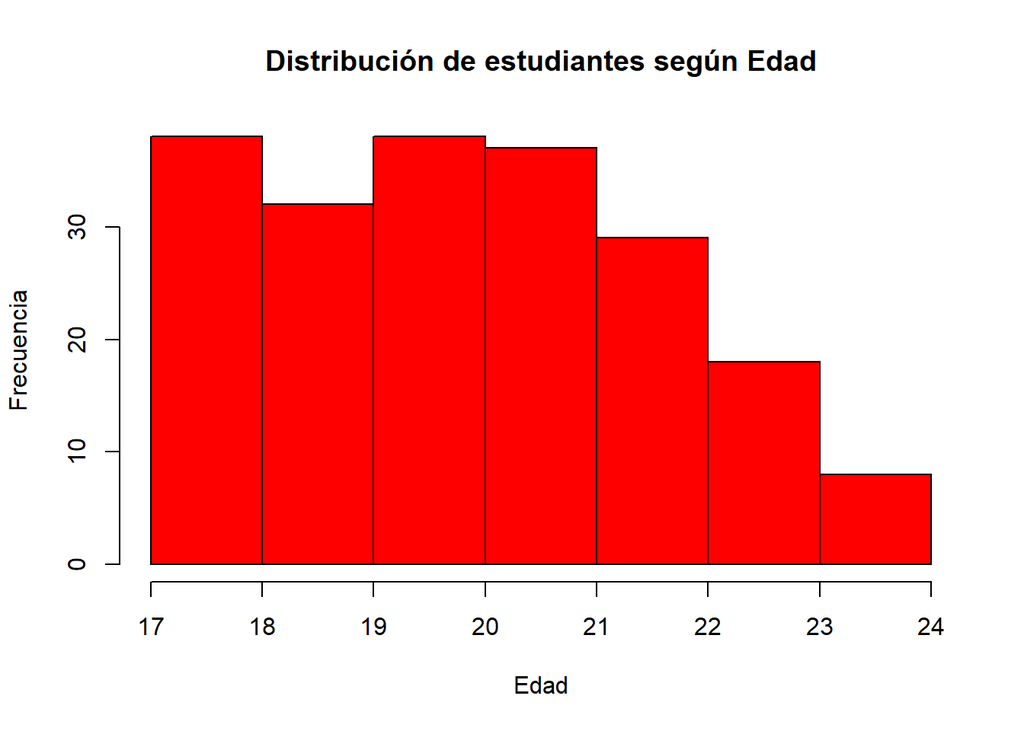

```r
hist(datos$Edad,main="Distribución de estudiantes según Edad",xlab="Edad",ylab="Frecuencia",col="red")
```

#### H.descanso

De los 200 estudiantes universitarios encuestados:

Según el histograma el tiempo de descanso de los estudiantes se concentra mayormente en 7 horas.

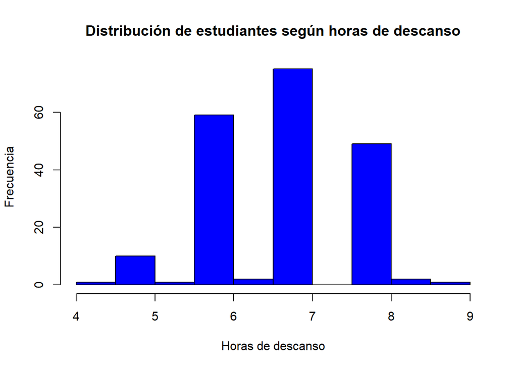

```r
hist(datos$H.descanso,main="Distribución de estudiantes según horas de descanso",xlab="Horas de descanso",ylab="Frecuencia",col="blue")
```

#### H.estudio

De los 200 estudiantes universitarios encuestados:

Según el histograma el tiempo de estudio de los estudiantes se concentra mayormente en entre 4 horas.

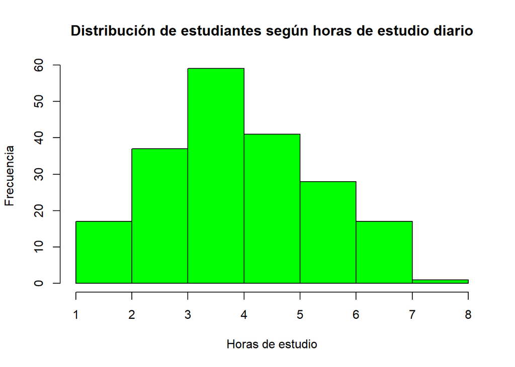

```r
hist(datos$H.estudio,main="Distribución de estudiantes según horas de estudio diario",xlab="Horas de estudio",ylab="Frecuencia",col="green")
```

#### T.traslado

De los 200 estudiantes universitarios encuestados:

Según el histograma el tiempo de traslado de los estudiantes se concentra mayormente en entre 0 y 60 minutos.

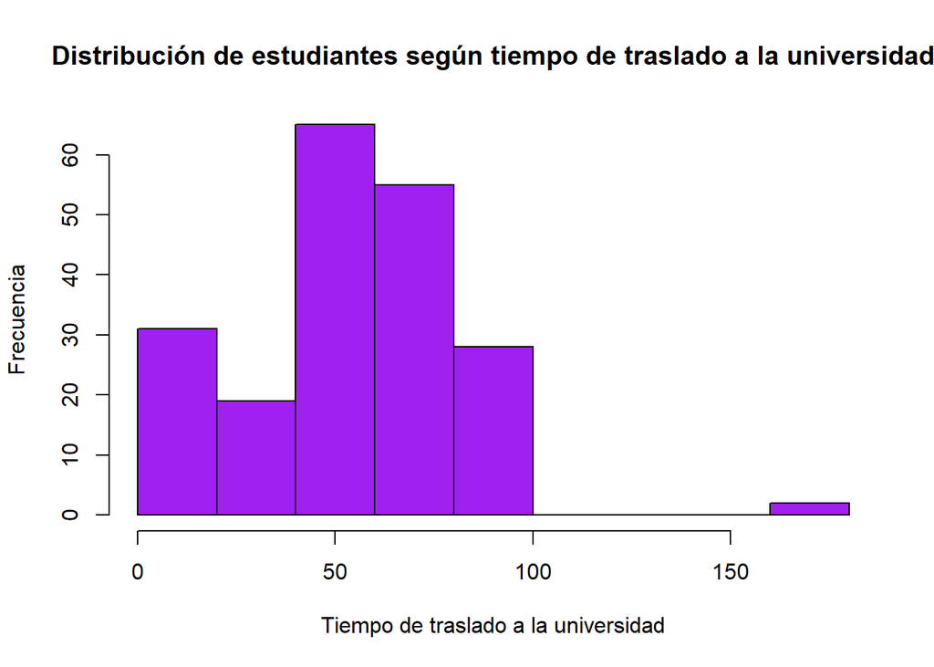

```r
hist(datos$T.traslado,main="Distribución de estudiantes según tiempo de traslado a la universidad",xlab="Tiempo de traslado a la universidad",ylab="Frecuencia",col="purple")
```

#### P.ciclo

De los 200 estudiantes universitarios encuestados:

Según el histograma el promedio ponderado de los estudiantes se concentra mayormente entre 13 y 16.

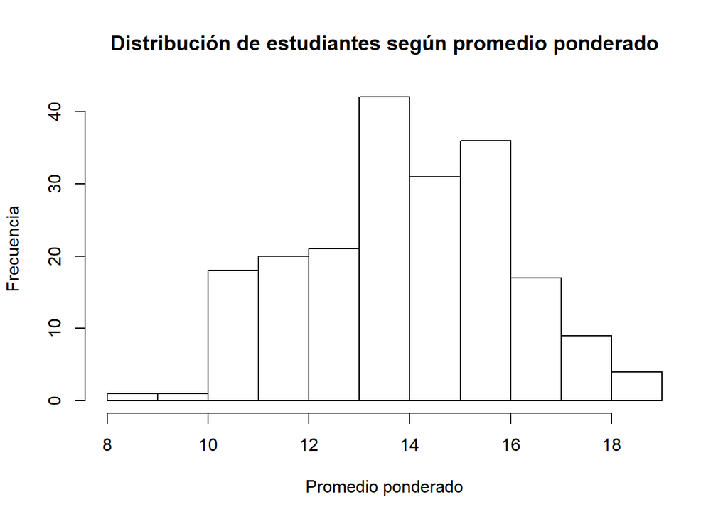

```r
hist(datos$P.ciclo,main="Distribución de estudiantes según promedio ponderado",xlab="Promedio ponderado",ylab="Frecuencia",col="white")
```

### **5.- Variables Cualitativas**

#### Nominales

A escala nominal se tiene

| Variable | Definición | Restricciones |
| --- | --- | --- |
| Sexo | Sexo del estudiante | Masculino, Femenino |
| Carrera | Carrera del estudiante | Administración y Negocios Digitales Bioingeniería Ciencia de la Computación Ciencia de Datos Ingeniería Ambiental Ingeniería Civil Ingeniería de la Energía Ingeniería Electrónica Ingeniería Industrial… |
| Ciclo | Ciclo del estudiante | 1, 2, 3, 4, 5, 6, 7, 8, 9,10 |
| E.laboral | Estado laboral del estudiante | No A tiempo parcial A tiempo completo |
| ————— | —————————————— | —————————————————- |
| Hogar | Integrantes de la familia del estudiante | Solo Familiares Amigos |
| ————— | —————————————— | —————————————————- |
| Asesoría | Si el estudiante recibe asesorías | Si, No |
| ————— | —————————————— | —————————————————- |
| L.estudio | Si se cuenta con espacio de estudio | Si, No |
| ————— | —————————————— | —————————————————- |
| S.sentimental | Situación sentimental | Si, No |
| ————— | —————————————— | —————————————————- |
| A.familiar | Apoyo familiar | 1 (ningún apoyo emocional), 2, 3, 4, 5 (apoyo al 100%) |

##### Sexo

```r
tabla=prop.table(table(datos$Sexo))
tabla
```

```
##
##  Femenino Masculino
##      0.39      0.61
```

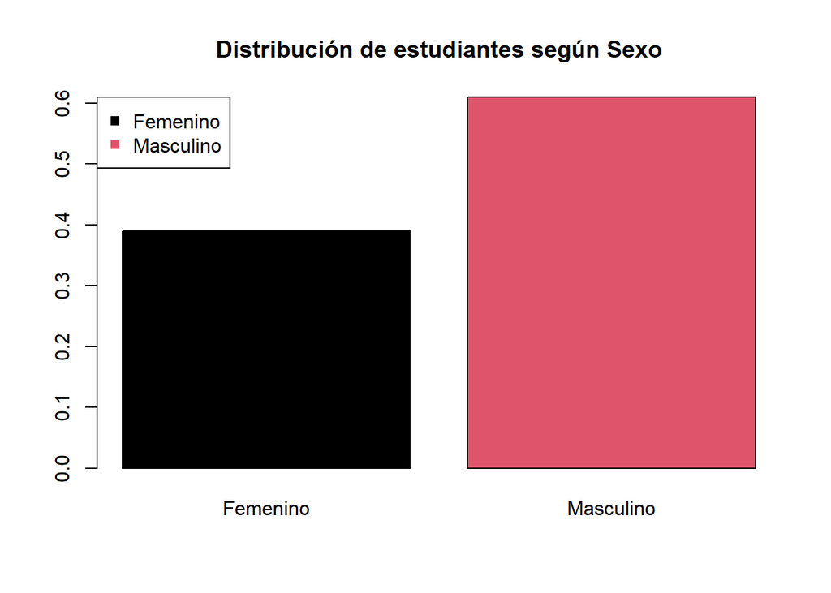

```r
barplot(tabla,col=1:2,main="Distribución de estudiantes según Sexo")
legend("topleft",legend=rownames(tabla), col=1:2, pch=15)
```

De acuerdo con los resultados, de los 200 estudiantes encuestados, el 39% son mujeres y el 61% son varones.

##### E.laboral

```r
tabla=prop.table(table(datos$E.laboral))
tabla
```

```
##
## A tiempo parcial               No
##             0.27             0.73
```

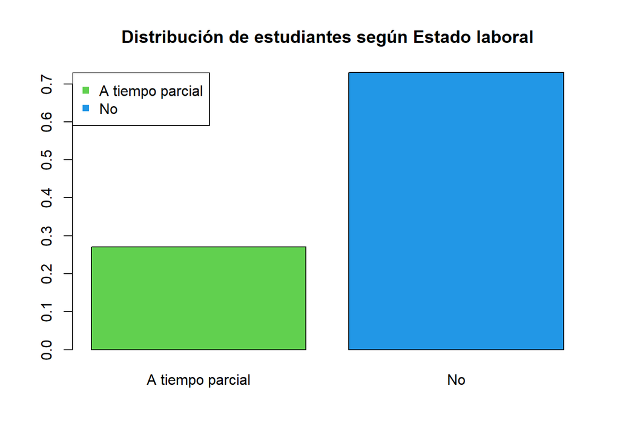

```r
barplot(tabla,col=3:4,main="Distribución de estudiantes según Estado laboral")
legend("topleft",legend=rownames(tabla), col=3:4, pch=15)
```

De acuerdo con los resultados, de los 200 estudiantes encuestados, el 27% trabajan a tiempo parcial y el 73% no trabajan.

###### Asesoría

```r
tabla=prop.table(table(datos$Asesorias))
tabla
```

```
##
##    No    Sí
## 0.755 0.245
```

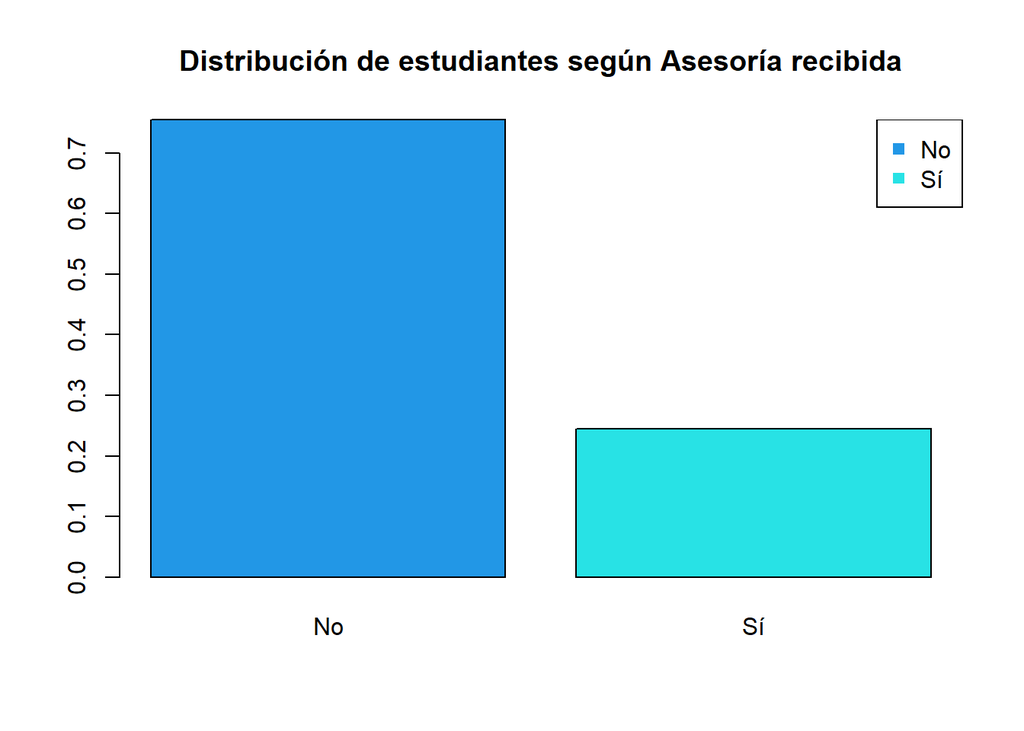

```r
barplot(tabla,col=4:5,main="Distribución de estudiantes según Asesoría recibida")
legend("topright",legend=rownames(tabla), col=4:5, pch=15)
```

De acuerdo con los resultados, de los 200 estudiantes encuestados, el 75.5% no reciben asesoría adicional y el 24.5% si reciben asesoría.

##### Situación sentimental

```r
tabla=prop.table(table(datos$S.sentimental))
tabla
```

```
##
##    No    Si
## 0.645 0.355
```

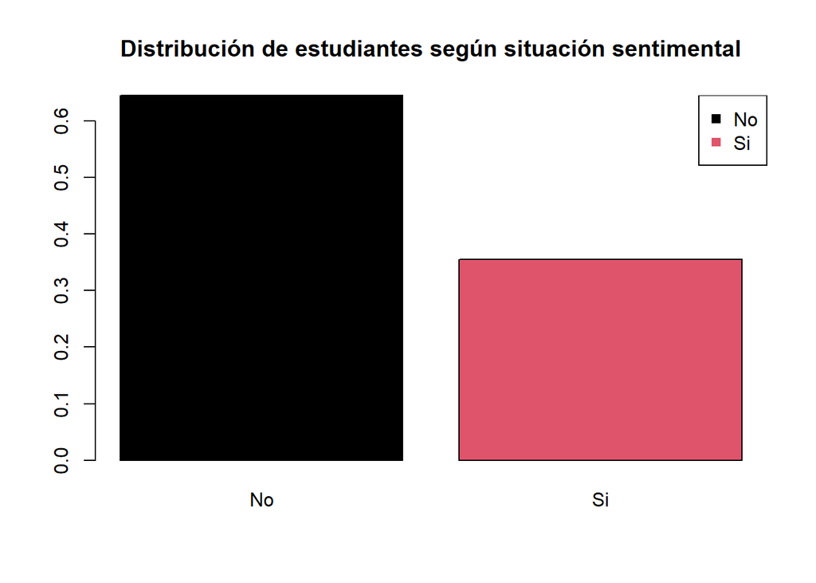

```r
barplot(tabla,col=1:2,main="Distribución de estudiantes según situación sentimental")
legend("topright",legend=rownames(tabla), col=1:2, pch=15)
```

De acuerdo con los resultados, de los 200 estudiantes encuestados, el 64.5% no mantiene una relación sentimental y el 35.5% si mantiene una relación sentimental.

#### Ordinales

A escala ordinal se tiene

| Variable | Definición | Restricciones |
| --- | --- | --- |
| N.padre | Nivel de instrucción del padre | Ninguno, Primaria, Secundaria, Bachillerato, Maestría,Doctorado |
| N.madre | Nivel de instrucción de la madre | Ninguno, Primaria, Secundaria, Bachillerato, Maestría, Doctorado |
| E.pagos | Escala de pagos del estudiante | Escala A, Escala B, Escala C, Escala D, Escala E |
| E.colegio | Nivel de exigencia del colegio | 1 (Muy baja), 2, 3, 4, 5 (Muy alta) |
| R.textos | Nivel de repaso de textos antes | 1 (Nunca), 2, 3, 4, 5 (Siempre) |
| R.temas | Nivel de repaso de temas | 1 (Nunca), 2, 3, 4, 5 (Siempre) |
| E.curso | Nivel de entendimiento de clases | 1 (Me cuesta mucho entender), 2, 3, 4, 5 (Me resulta fácil entender) |
| N.Generales | Dificultad de cursos generales | Muy fácil, Fácil, Regular, Difícil, Muy difícil |
| N.Carrera | Dificultad de cursos de carrera | Muy fácil, Fácil, Regular, Difícil, Muy difícil |
| N.Humanidades | Dificultad de cursos de humanidades | Muy fácil, Fácil, Regular, Difícil, Muy difícil |
| N.Gestión | Dificultad de cursos de gestión | Muy fácil, Fácil, Regular, Difícil, Muy difícil |

##### Nivel de repaso antes de clase

De acuerdo con los resultados, de los 200 estudiantes encuestados:

```r
datos$R.textos=as.factor(datos$R.textos)
levels(datos$R.textos)=list("Nunca"=1,"Casi nunca"=2,"A veces"=3,"Casi siempre"=4,"Siempre"=5)
tabla=prop.table(table(datos$R.textos))
tabla
```

```
##
##        Nunca   Casi nunca      A veces Casi siempre      Siempre
##        0.015        0.120        0.310        0.485        0.070
```

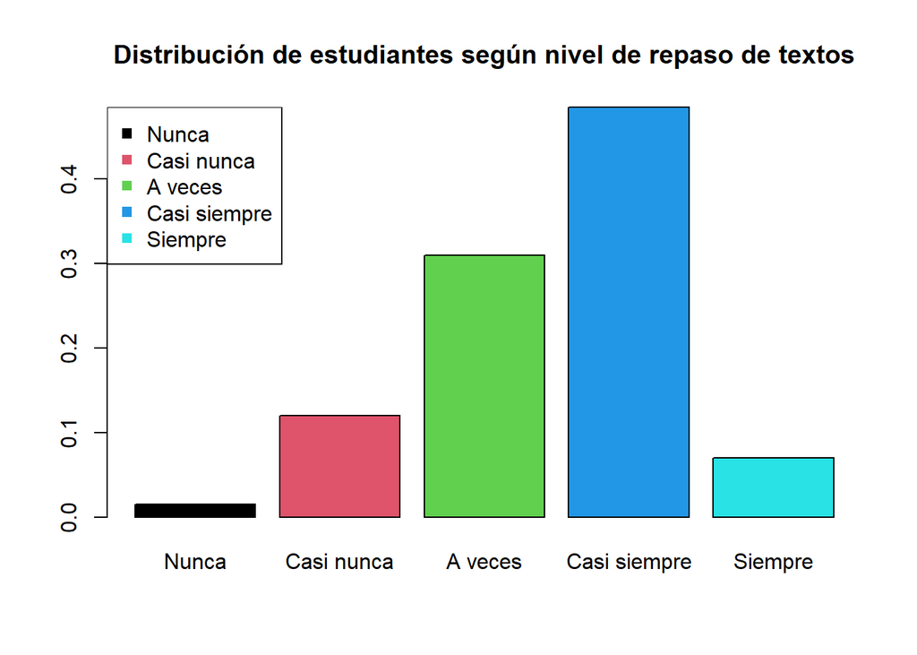

```r
barplot(tabla,col=1:5,main="Distribución de estudiantes según nivel de repaso de textos")
legend("topleft",legend=rownames(tabla), col=1:5, pch=15)
```

##### Dificultad de cursos de carrera

De acuerdo con los resultados, de los 200 estudiantes encuestados:

```r
datos$N.Carrera=as.factor(datos$N.Carrera)
levels(datos$N.Carrera)=list("Muy fácil"=1,"Fácil"=2,"Regular"=3,"Difícil"=4,"Muy difícil"=5)
tabla=prop.table(table(datos$N.Carrera))
tabla
```

```
##
##   Muy fácil       Fácil     Regular     Difícil Muy difícil
##  0.02189781  0.46715328  0.51094891  0.00000000  0.00000000
```

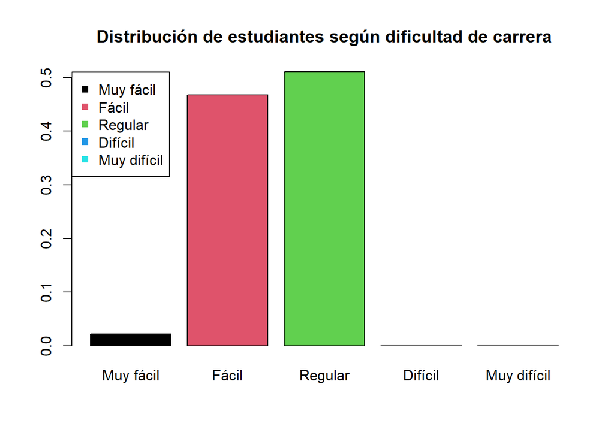

```r
barplot(tabla,col=1:5,main="Distribución de estudiantes según dificultad de carrera")
legend("topleft",legend=rownames(tabla), col=1:5, pch=15)
```

##### Apoyo familiar

De acuerdo con los resultados, de los 200 estudiantes encuestados:

- El 21% de los estudiantes casi nunca tiene el apoyo emocional de su familia.
- El 17.5% de los estudiantes a veces tiene el apoyo emocional de su familia.
- El 38% de los estudiantes casi siempre tiene el apoyo emocional de su familia.
- El 23.5% de los estudiantes siempre tiene el apoyo emocional de su familia.

```r
datos$A.familiar=as.factor(datos$A.familiar)
levels(datos$A.familiar)=list("Nunca"=1,"Casi nunca"=2,"A veces"=3,"Casi siempre"=4,"Siempre"=5)
tabla=prop.table(table(datos$A.familiar))
tabla
```

```
##
##        Nunca   Casi nunca      A veces Casi siempre      Siempre
##        0.000        0.210        0.175        0.380        0.235
```

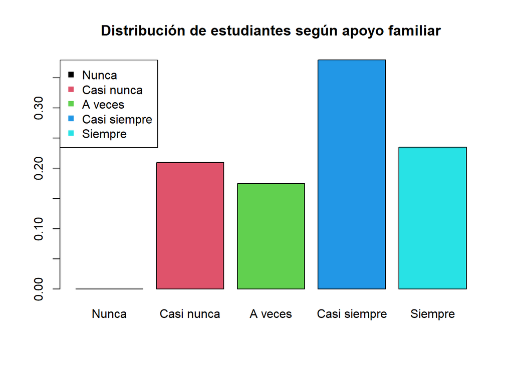

```r
barplot(tabla,col=1:5,main="Distribución de estudiantes según apoyo familiar")
legend("topleft",legend=rownames(tabla), col=1:5, pch=15)
```

## **6.- Análisis Bivariado**

### **6.1.- Cualitativas vs cuantitativas**

#### E.colegio vs P.ciclo

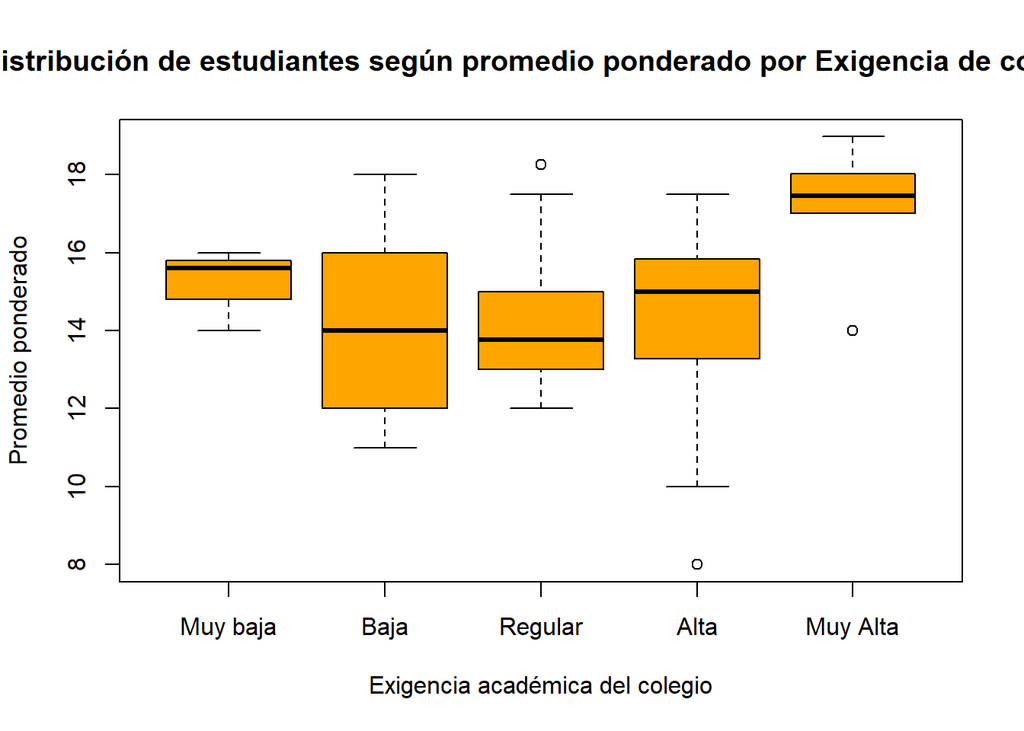

```r
datos$E.colegio=as.factor(datos$E.colegio)
levels(datos$E.colegio)=list("Muy baja"=1,"Baja"=2,"Regular"=3,"Alta"=4,"Muy Alta"=5)
boxplot(datos$P.ciclo~datos$E.colegio,xlab="Exigencia académica del colegio",ylab="Promedio ponderado",col="orange",main="Distribución de estudiantes según promedio ponderado por Exigencia de colegio")
```

#### R.textos vs P.ciclo

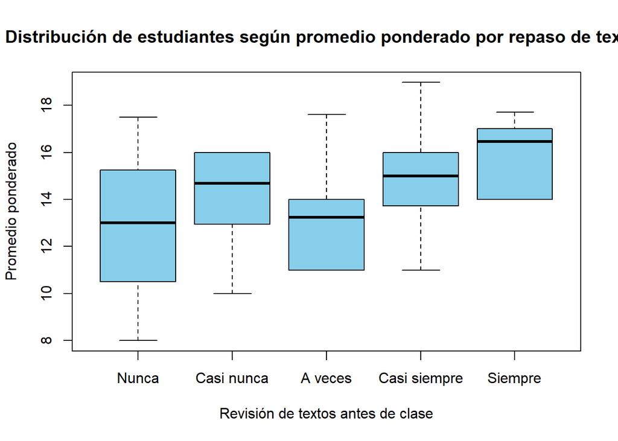

```r
boxplot(datos$P.ciclo~datos$R.textos,xlab="Revisión de textos antes de clase",ylab="Promedio ponderado",col="skyblue",main="Distribución de estudiantes según promedio ponderado por repaso de textos")
```

#### A.familiar vs P.ciclo

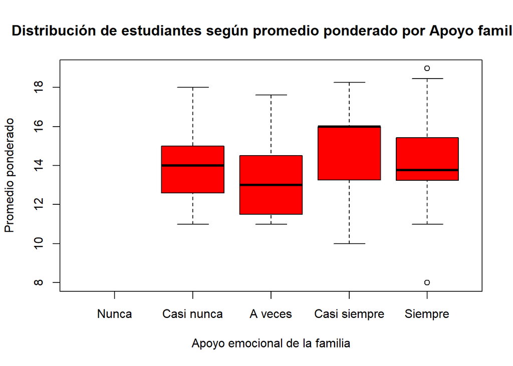

```r
boxplot(datos$P.ciclo~datos$A.familiar,xlab="Apoyo emocional de la familia",ylab="Promedio ponderado",col="red",main="Distribución de estudiantes según promedio ponderado por Apoyo familiar")
```

#### S.sentimental vs P.ciclo

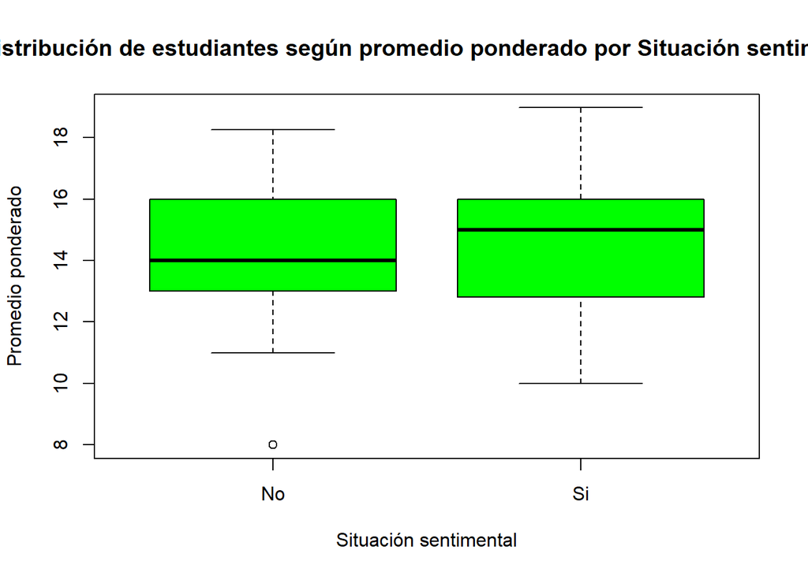

```r
boxplot(datos$P.ciclo~datos$S.sentimental ,xlab="Situación sentimental",ylab="Promedio ponderado",col="green",main="Distribución de estudiantes según promedio ponderado por Situación sentimental")
```

### **6.2- Cualitativas vs cualitativas**

#### R.textos vs sexo

```r
tabla=prop.table(table(datos$R.textos,datos$Sexo),margin =2)
tabla
```

```
##
##                  Femenino  Masculino
##   Nunca        0.00000000 0.02459016
##   Casi nunca   0.14102564 0.10655738
##   A veces      0.26923077 0.33606557
##   Casi siempre 0.51282051 0.46721311
##   Siempre      0.07692308 0.06557377
```

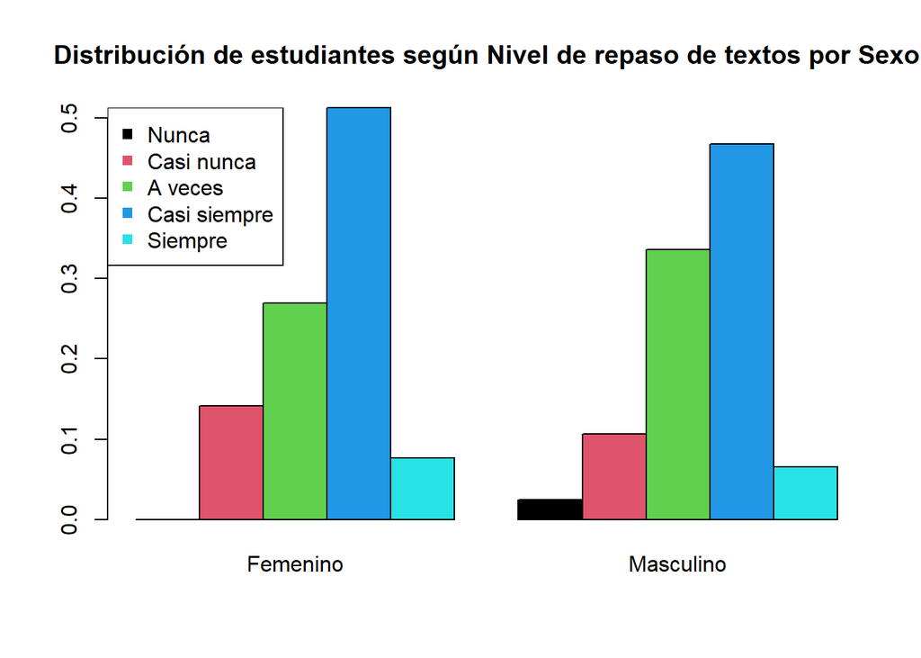

```r
barplot(tabla,beside=TRUE,col=1:5,main="Distribución de estudiantes según Nivel de repaso de textos por Sexo")
legend("topleft",legend=rownames(tabla),
  col=1:5, pch=15)
```

Se observa un patrón similar de comportamiento de repaso de textos en ambos sexos, es decir la forma de estudio es similar predominando la categoría casi siempre.

#### S.sentimental vs sexo

```r
tabla=prop.table(table(datos$S.sentimental,datos$Sexo),margin=2)
tabla
```

```
##
##       Femenino Masculino
##   No 0.6153846 0.6639344
##   Si 0.3846154 0.3360656
```

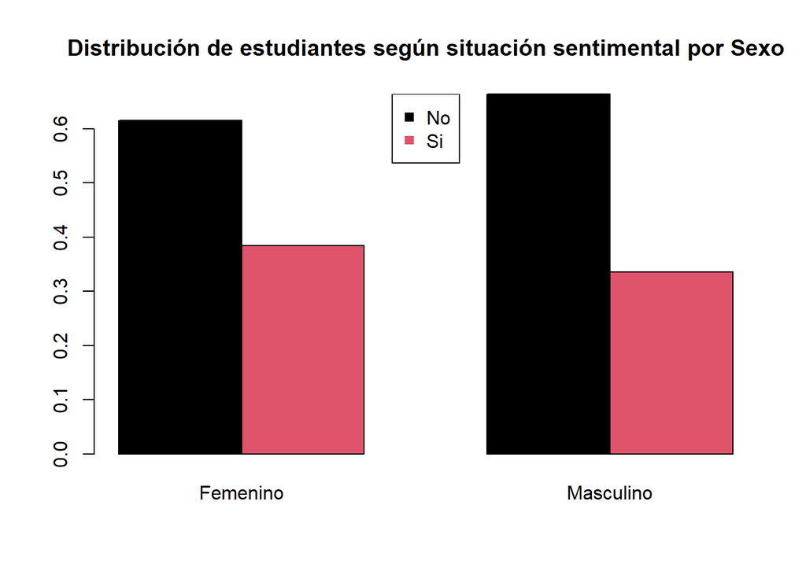

```r
barplot(tabla,beside=TRUE,col=1:2,main="Distribución de estudiantes según situación sentimental por Sexo")
legend("top",legend=rownames(tabla),
  col=1:2, pch=15)
```

Se observa un patrón similar de comportamiento en la situación sentimental en ambos sexos, predominando la soltería.

#### Apoyo familiar vs sexo

```r
tabla=prop.table(table(datos$A.familiar,datos$Sexo),margin =2)
tabla
```

```
##
##                 Femenino Masculino
##   Nunca        0.0000000 0.0000000
##   Casi nunca   0.1410256 0.2540984
##   A veces      0.1923077 0.1639344
##   Casi siempre 0.3974359 0.3688525
##   Siempre      0.2692308 0.2131148
```

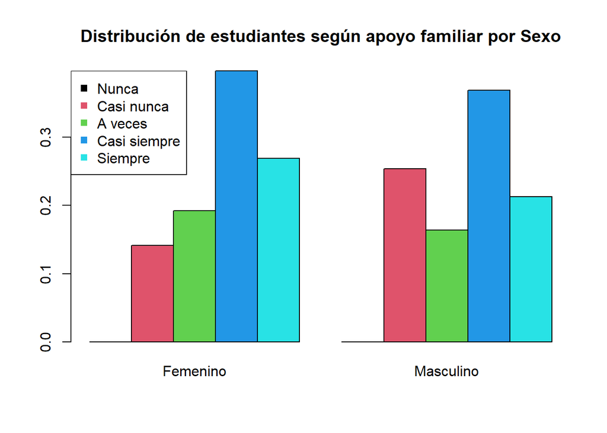

```r
barplot(tabla,beside=TRUE,col=1:5,main="Distribución de estudiantes según apoyo familiar por Sexo")
legend("topleft",legend=rownames(tabla),
  col=1:5, pch=15)
```

No se observa un patrón de apoyo familiar entre hombres y mujeres. Existe un porcentaje regular de varones que casi nunca tienen el apoyo familiar mientras que las mujeres casi siempre tienen el apoyo familiar.

#### Dificultad de carrera vs sexo

```r
tabla=prop.table(table(datos$N.Carrera,datos$Sexo),margin =2)
tabla
```

```
##
##                 Femenino  Masculino
##   Muy fácil   0.02040816 0.02272727
##   Fácil       0.44897959 0.47727273
##   Regular     0.53061224 0.50000000
##   Difícil     0.00000000 0.00000000
##   Muy difícil 0.00000000 0.00000000
```

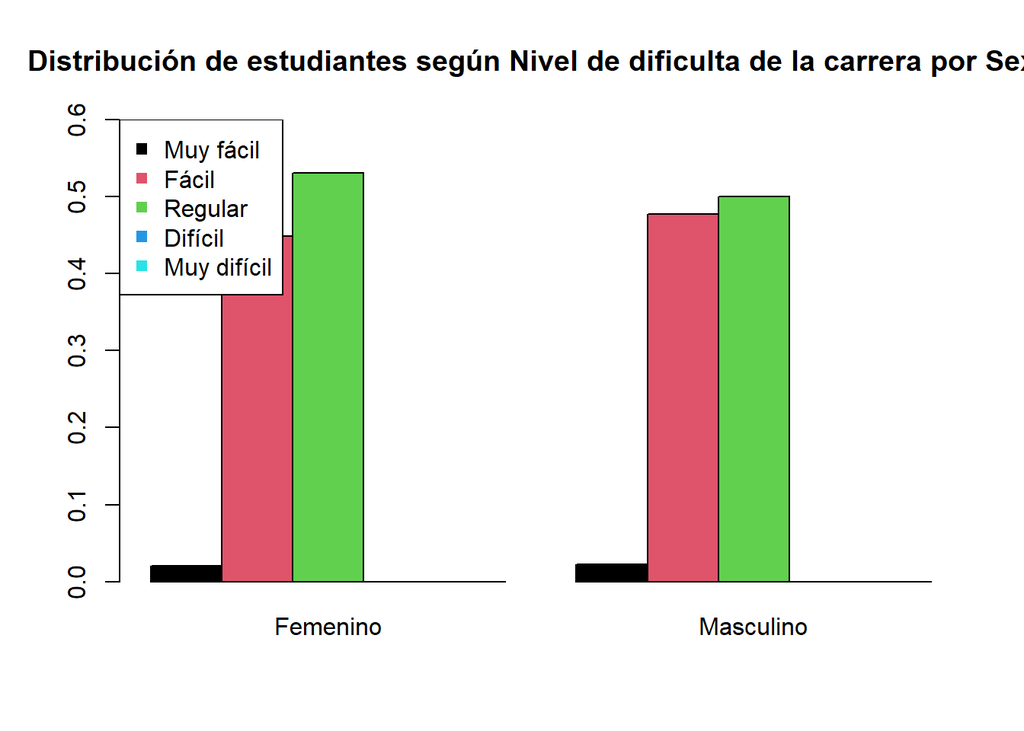

```r
barplot(tabla,beside=TRUE,col=1:5,ylim=c(0,0.6),main="Distribución de estudiantes según Nivel de dificulta de la carrera por Sexo")
legend("topleft",legend=rownames(tabla),
  col=1:5, pch=15)
```

Se observa un patrón casi similar de comportamiento de nivel de dificultad de la carrera en ambos sexos, es decir la percepción de dificultad es similar predominando las categoría regular y fácil.

### **6.3- Cuantitativas vs cuantitativas**

#### P.ciclo vs Horas de estudio

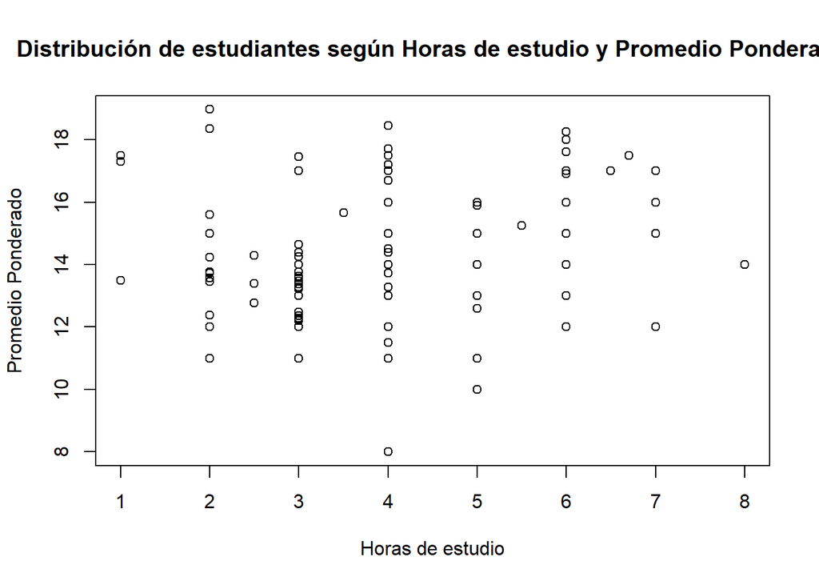

```r
plot(datos$H.estudio,datos$P.ciclo,xlab="Horas de estudio",ylab="Promedio Ponderado",main="Distribución de estudiantes según Horas de estudio y Promedio Ponderado")
```

```r
cor(datos$H.estudio,datos$P.ciclo)
```

```
## [1] 0.1790539
```

#### P.ciclo vs Edad

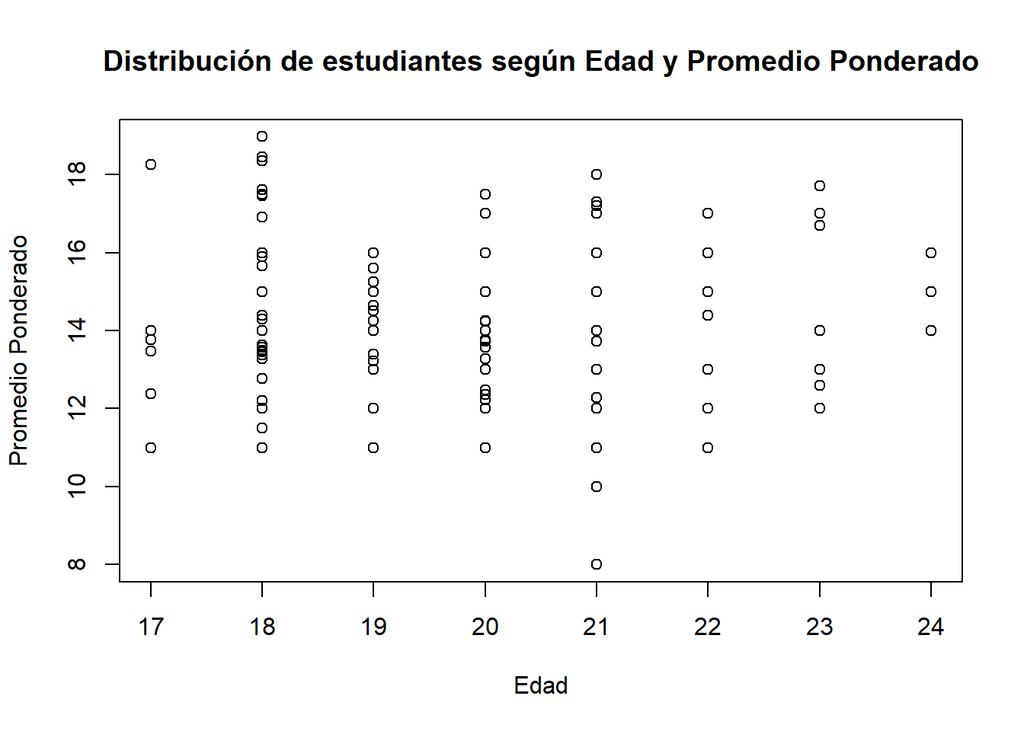

```r
plot(datos$Edad,datos$P.ciclo,xlab="Edad",ylab="Promedio Ponderado",main="Distribución de estudiantes según Edad y Promedio Ponderado")
```

```r
cor(datos$Edad,datos$P.ciclo)
```

```
## [1] 0.09285746
```

#### Edad vs Horas de descanso

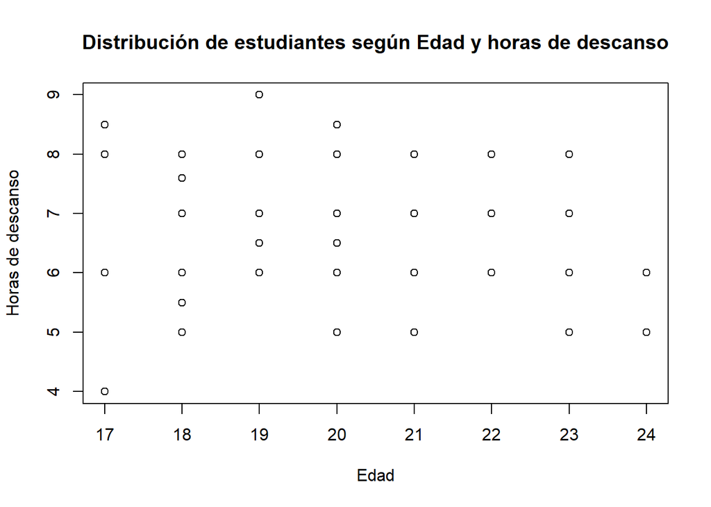

```r
plot(datos$Edad,datos$H.descanso,xlab="Edad",ylab="Horas de descanso",main="Distribución de estudiantes según Edad y horas de descanso")
```

```r
cor(datos$Edad,datos$H.descanso)
```

```
## [1] -0.3479528
```

#### Edad vs Horas de estudio

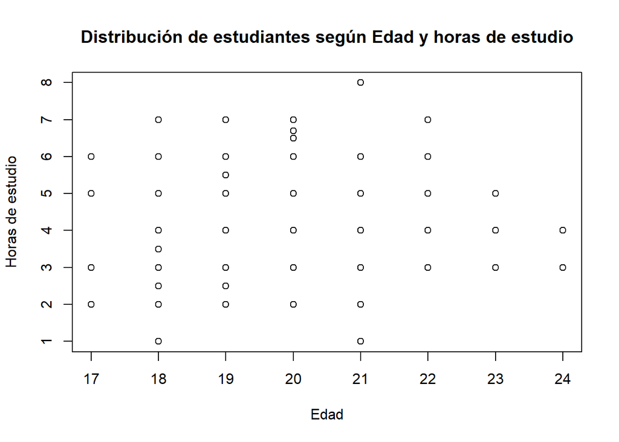

```r
plot(datos$Edad,datos$H.estudio,xlab="Edad",ylab="Horas de estudio",main="Distribución de estudiantes según Edad y horas de estudio")
```

```r
cor(datos$Edad,datos$H.estudio)
```

```
## [1] 0.03124852
```

## **7.- Tablas cruzadas**

### **Sexo y Hogar**

```r
tabla1=addmargins(table(datos$Sexo,datos$Hogar))
tabla1
```

```
##
##             Amigos Familiares Solo Sum
##   Femenino       1         72    5  78
##   Masculino      2         98   22 122
##   Sum            3        170   27 200
```

### **Sexo y Carrera**

```r
tabla2=addmargins(table(datos$Carrera,datos$Sexo))
tabla2
```

```
##
##                                       Femenino Masculino Sum
##   Administración y Negocios Digitales        2         0   2
##   Bioingeniería                             14         3  17
##   Ciencia de Datos                           2         4   6
##   Ciencia de la Computación                  3         5   8
##   Ingeniería Ambiental                      11         6  17
##   Ingeniería Civil                           5        25  30
##   Ingeniería de la Energía                   5        12  17
##   Ingeniería Electrónica                     4        20  24
##   Ingeniería Industrial                     21         6  27
##   Ingeniería Mecánica                        2        22  24
##   Ingeniería Mecatrónica                     8        13  21
##   Ingeniería Química                         1         6   7
##   Sum                                       78       122 200
```

- De un total de 200 estudiantes universitarios encuestados, 17 son de la carrera de Bioingeniería, 2 de Administración y Negocios Digitales, 6 de Ciencia de Datos, 8 de Ciencia de la Computación, 17 de Ingeniería Ambiental, 30 de Ingeniería Civil, 17 de Ingeniería de la Energía, 24 de Ingeniería Electrónica, 27 de Ingeniería Industrial, 24 de Ingeniería Mecánica, 21 de Ingeniería Mecatrónica y 7 de Ingeniería Química.
- De un total de 200 estudiantes universitarios encuestados, la carrera con menos alumnos encuestados es Administración y Negocios Digitales con 2 alumnos y la carrera con mayor número de alumnos encuestados es Ingeniería Civil con 30 alumnos.

### **Sexo y situación sentimental**

```r
tabla3=addmargins(table(datos$Sexo,datos$S.sentimental))
tabla3
```

```
##
##              No  Si Sum
##   Femenino   48  30  78
##   Masculino  81  41 122
##   Sum       129  71 200
```

### **Sexo y Tercio al que pertenece**

```r
tabla4=addmargins(table(datos$Tertil,datos$Sexo))
tabla4
```

```
##
##                                   Femenino Masculino Sum
##   Tercio inferior (inferior 33% )        0         1   1
##   Tercio inferior (inferior 33%)         5        23  28
##   Tercio medio (medio 33%)              38        48  86
##   Tercio superior (top 33%)             35        50  85
##   Sum                                   78       122 200
```

- De un total de 200 estudiantes universitarios encuestados, 78 son mujeres, además en el Tercio inferior (inferior 33%) se encuentran 5 mujeres, en el Tercio medio (medio 33%) se encuentran 38 mujeres y en el Tercio superior (top 33%) se encuentran 35 mujeres. .
- De un total de 200 estudiantes universitarios encuestados, 122 son hombres, además en el Tercio inferior (inferior 33%) se encuentran 24 hombres, en el Tercio medio (medio 33%) se encuentran 48 hombres y en el Tercio superior (top 33%) se encuentran 50 hombres.

## **7.1.- Eventos estudiados**

Los eventos que intervienen en el cálculo de probabilidad son:

- M: El estudiante es mujer
- H: El estudiante es hombre
- F: El estudiante vive con su familia
- D: El estudiante es de la carrera de Ciencia de Datos
- S: El estudiante se encuentra en una relación sentimental
- T: El estudiante pertenece al tercio superior

### **7.2.- Aplicación de axiomas de probabilidades**

### **Sexo y Hogar**

#### **Sabiendo que un estudiante vive con sus familiares, ¿Cual es la probabilidad de que sea hombre?**

$P(H|D)=\frac{98/200}{170/200}$

```r
tabla1[2,2]/200/(tabla1[3,2]/200)
```

```
## [1] 0.5764706
```

#### **Si se elige un estudiante al azar, ¿cuál es la probabilidad de que sea mujer o viva con sus familiares?**

```r
(tabla1[1,4]+tabla1[2,3]-tabla1[1,2])/200
```

```
## [1] 0.14
```

#### **Si se elige un estudiante al azar, ¿cuál es la probabilidad de que no viva con sus familiares?**

```r
1-tabla1[2,3]/200
```

```
## [1] 0.89
```

### **Sexo y Carrera**

#### **Sabiendo que el estudiante es de la carrera de Ciencia de Datos, ¿cuál es la probabilidad de que de que sea hombre?**

$P(H|D)=\frac{4/200}{6/200}$

```r
tabla2[3,2]/200/(tabla2[3,3]/200)
```

```
## [1] 0.6666667
```

#### **Si se elige un estudiante al azar, ¿cuál es la probabilidad de que sea mujer y estudie Ciencia de Datos?**

$P(M\cap D)=2/200$

```r
tabla2[3,1]/200
```

```
## [1] 0.01
```

#### **Si se elige un estudiante al azar, ¿cuál es la probabilidad de que no estudie Ciencia de Datos?**

$P(D')=1-6/200$

```r
1-tabla2[3,3]/200
```

```
## [1] 0.97
```

### **Sexo y Situación sentimental**

#### **Sabiendo que el encuestado es mujer ¿Cual es la probabilidad de que se encuetre en una Situación sentimental?**

$P(S|M)=\frac{30/200}{78/200}$

```r
tabla3[1,2]/200/(tabla3[1,3]/200)
```

```
## [1] 0.3846154
```

#### **Si se elige un estudiante al azar, ¿cuál es la probabilidad de que sea mujer o se encuentre en una relación sentimental?**

$P(M \cap S)=P(M)+P(S)- P(M \cap S)=(78+71-30)/200$

```r
(tabla3[1,3]+tabla3[3,2]-tabla3[1,2])/200
```

```
## [1] 0.595
```

#### **Cual es la probabilidad de que una persona no este en una situación sentimental y no sea de género masculino**

```r
1-tabla3[2,2]/200
```

```
## [1] 0.795
```

### **Sexo y Tercio al que pertenece en el colegio**

#### **Sabiendo que es mujer ¿Cual es la probabilidad de que pertenezca al Tercio Superior en el colegio?**

```r
tabla4[3,1]/200/(tabla4[4,1]/200)
```

[output not shown]

#### **Si se elige un estudiante al azar, ¿cuál es la probabilidad de que pertenezca al tercio superior y sea mujer?**

```r
tabla4[3,1]/200
```

```
## [1] 0.19
```

#### **Si se elige un estudiante al azar, ¿cuál es la probabilidad de que pertenezca al tercio superior o sea mujer?**

```r
(tabla4[3,3]+tabla4[4,1]-tabla4[3,1])/200
```

```
## [1] 0.415
```

## **8.- Propuestas de modelos estudiados**

A continuación se emplean los modelos de probabilidad aplicables a nuestras variables

### **8.1.- Variables aleatorias discretas**

#### **Distribución Binomial**

##### **Variable: Sexo**

De acuerdo con la tabla la probabilidad de que un estudiante sea mujer es de 0.39. Si se asume que está probabilidad se mantiene en los próximos ciclos.

###### Se desea formar una comitiva de 25 estudiantes donde la selección es al azar, ¿cuál es la probabilidad de que la conformen 10 mujeres?

Sea X: número de mujeres que conforman la directiva

$X~Binom(n=25,p=0.39)$

```r
dbinom(10,25,0.39)
```

```
## [1] 0.1603159
```

De la comitiva de 25 estudiantes donde la selección es al azar, la probabilidad de que la comitiva tenga 10 mujeres es de 0.1603.

###### Se desea formar una comitiva de 25 estudiantes donde la selección es al azar, ¿cuál es la probabilidad de que la conformen menos de 10 mujeres?

$P(X<10)=P(x\leq 9)=\sum_{x=0}^{x=9}C_x^{25}*0.39^x*(1-0.39)^{25-x}=$

```r
pbinom(9,25,0.39)
```

```
## [1] 0.4653472
```

De la comitiva de 25 estudiantes donde la selección es al azar, la probabilidad de que la comitiva la conformen menos de 10 mujeres es de 0.4653.

###### Se desea formar una comitiva de 25 estudiantes donde la selección es al azar, ¿cuál es la probabilidad de que la conformen más de 10 mujeres?

$P(X>10)=1-P(x\leq 10)=1-\sum_{x=0}^{x=10}C_x^{25}*0.39^x*(1-0.39)^{25-x}=$

```r
1-pbinom(10,25,0.39)
```

```
## [1] 0.3743369
```

De la comitiva de 25 estudiantes donde la selección es al azar, la probabilidad de que la comitiva la conformen más de 10 mujeres es de 0.3743.

#### **Distribución Hipergeométrica**

##### **Variable: Sexo**

Asumiendo que el total de estudiantes encuestados comparten una misma sección.

###### Se desea formar una comitiva de 25 estudiantes donde la selección es al azar, ¿cuál es la probabilidad de que la conformen 10 mujeres?

Los parámetros encontrados son: N=200, M=78, n=25

$X~Hiper(N=200,M=78,n=25)$

$P(X=10)=\frac{C_{10}^{78} C^{200-78}_{25-10}}{C^{200}_{25}} =$

```r
dhyper(10,78,200-78,25)
```

```
## [1] 0.1713371
```

De la comitiva de 25 estudiantes donde la selección es al azar, la probabilidad de que la comitiva la conformen 10 mujeres es de 0.1713.

###### Se desea formar una comitiva de 25 estudiantes donde la selección es al azar, ¿cuál es la probabilidad de que la conformen menos de 10 mujeres?

$P(X<10)=P(x\leq 9) =\sum_{x=0}^{x=9} \frac{C_{x}^{78} C^{200-78}_{25-x}}{C^{200}_{25}} =$

```r
phyper(9,78,200-78,25)
```

```
## [1] 0.46132
```

De la comitiva de 25 estudiantes donde la selección es al azar, la probabilidad de que la comitiva la conformen menos de 10 mujeres es de 0.4613.

###### Se desea formar una comitiva de 25 estudiantes donde la selección es al azar, ¿cuál es la probabilidad de que la conformen más de 10 mujeres?

$P(X>10)=1-P(x\leq 10) =1-\sum_{x=0}^{x=10} \frac{C_{x}^{78} C^{200-78}_{25-x}}{C^{200}_{25}} =$

```r
1-phyper(10,78,200-78,25)
```

```
## [1] 0.3673429
```

De la comitiva de 25 estudiantes donde la selección es al azar, la probabilidad de que la comitiva la conformen más de 10 mujeres es de 0.3673.

#### **Distribución Poisson**

##### **Variable: Horas de descanso a día**

La variable horas de descanso al día se puede modelar con el modelo Poisson pues contien información diaria de las horas de sueño.

```r
mean(datos$H.descanso)
```

```
## [1] 6.8455
```

###### ¿Cuál es la probabilidad de que un estudiante descanse 8 horas?

x: Número de horas de descanso al día

```r
dpois(8,6.505)
```

```
## [1] 0.1189521
```

La probabilidad de que un estudiante descanse 8 horas al día es 0.1189, por lo tanto el 11.89% de los estudiantes descansan 8 horas diarias.

###### ¿Cuál es la probabilidad de que un estudiante descanse menos de 8 horas?

```r
ppois(7,6.505)
```

```
## [1] 0.6720265
```

La probabilidad de que un estudiante descanse menos de 8 horas al día es 0.6720, por lo tanto el 67.20% de los estudiantes descansan menos de 8 horas diarias.

###### ¿Cuál es la probabilidad de que un estudiante descanse más de 8 horas?

$P(X>8)=1-P(x \leq 8)=\sum_{x=0}^{x=8} \frac{e^{-6.505} 6.505^{x}}{x!}$

```r
1-ppois(8,6.505)
```

```
## [1] 0.2090214
```

La probabilidad de que un estudiante descanse más de 8 horas al día es 0.2090, por lo tanto el 20.90% de los estudiantes descansan más de 8 horas diarias.

### **8.2- Variables aleatorias continuas**

#### **Distribución Exponencial**

##### **Variable: Tiempo de traslado**

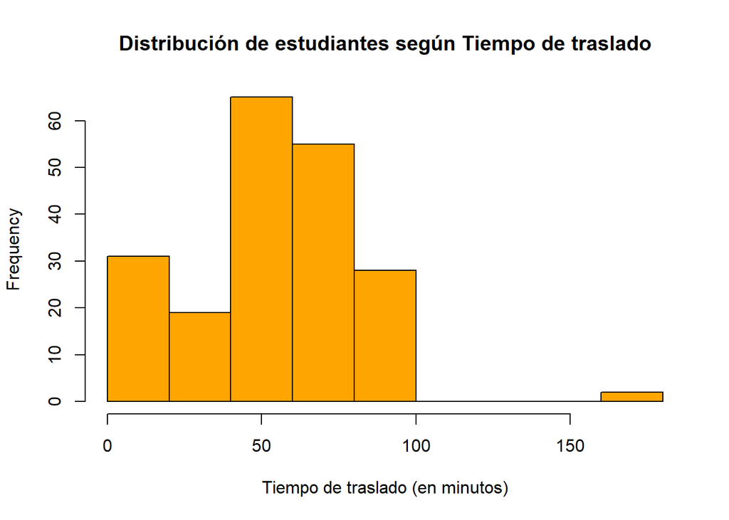

```r
hist(datos$T.traslado,xlab="Tiempo de traslado (en minutos)",main="Distribución de estudiantes según Tiempo de traslado",col="orange")
```

```r
mean(datos$T.traslado)
```

```
## [1] 58.24
```

x: tiempo de traslado a la universidad (en minutos)

###### ¿Cuál es la probabilidad de que un estudiante demore en trasladarse a la universidad menos de 45 minutos?

$P(X<45$

```r
pexp(45,1/54.575)
```

```
## [1] 0.5615692
```

$P(X>45=1-P(X<45)$

```r
1-pexp(45,1/54.575)
```

```
## [1] 0.4384308
```

```r
pexp(45,1/54.575,lower.tail = FALSE)
```

```
## [1] 0.4384308
```

El 43.84% de los estudiantes demoran en trasladarse a la universidad más de 45 minutos.

###### ¿Cuál es la probabilidad de que un estudiante demore en trasladarse a la universidad entre 40 y 60 minutos?

$P(40<X<60) = P(X<60)-P(x<40)$

```r
pexp(60,1/54.575)-pexp(40,1/54.575)
```

```
## [1] 0.1474267
```

El 14.74% de los estudiantes demoran en trasladarse a la universidad entre 40 y 60 minutos.

#### **Distribución Normal**

##### **Variable: Promedio ponderado**

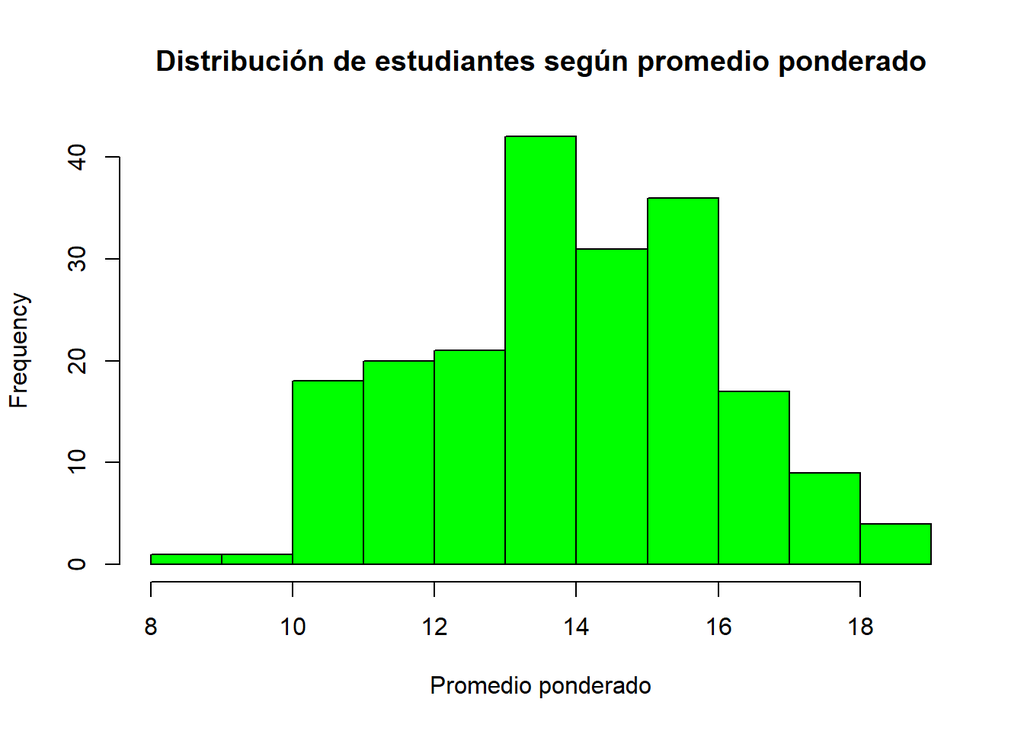

```r
hist(datos$P.ciclo,xlab="Promedio ponderado",main="Distribución de estudiantes según promedio ponderado",col="green")
```

$H_0:$ Los datos del promedio ponderado se ajustan a una distribución Normal

$H_1:$ Los datos del promedio ponderado NO se ajustan a una distribución Normal

```r
library(nortest)
ad.test(datos$P.ciclo)
```

```
##
##  Anderson-Darling normality test
##
## data:  datos$P.ciclo
## A = 1.7829, p-value = 0.0001414
```

```r
mean(datos$P.ciclo); sd(datos$P.ciclo)
```

```
## [1] 14.2925
```

```
## [1] 2.035699
```

x: Promedio ponderado acumulado

###### ¿Cuál es la probabilidad de que un estudiante tenga menos de 15 en su promedio ponderado?

$P(X<15$

```r
pnorm(15,14.2168,1.470853)
```

```
## [1] 0.7028033
```

###### ¿Cuál es la probabilidad de que un estudiante tenga más de 15 en su promedio ponderado?

$P(X>15=1-P(X<15)$

```r
1-pnorm(15,14.2168,1.470853)
```

```
## [1] 0.2971967
```

```r
pnorm(15,14.2168,1.470853,lower.tail = FALSE)
```

```
## [1] 0.2971967
```

El 29.72% de los estudiantes tienen un promedio ponderado mayor a 15.

###### ¿Cuál es la probabilidad de que un estudiante tenga entre 14 y 16 de promedio ponderado?

$P(14<X<16) = P(X<16)-P(x<14)$

```r
pnorm(16,14.2168,1.470853)-pnorm(14,14.2168,1.470853)
```

```
## [1] 0.4459031
```

El 44.59% de los estudiantes tienen un promedio ponderado entre 14 y 16.

## **Diagrama de Gantt**

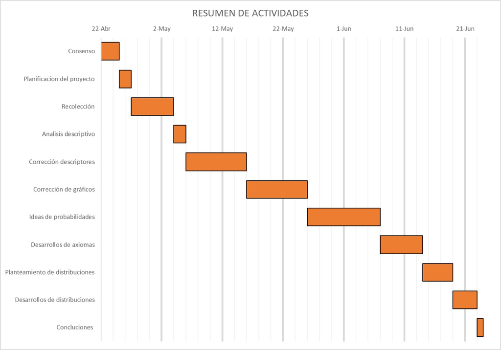